# Bellabeat_Final

Muazzam

2024-07-22

# Functions and Setup

The following code defines the setup and libraries that are used in this analysis

```r
# library(ggplot2)
library(tidyr)
library(stringr)
library(janitor)
library(here)
library(ggplot2)
library(skimr)
library(dplyr)
```

The following code defines the functions that will be used in the case study

```r
read = function(s1){
  paste(params$root,s1,sep="") %>%
    read.csv()
}

camel_to_snake <- function(camel_case_names) {
  # Use str_replace_all from the stringr package to add underscores before uppercase letters
  snake_case_names <- str_replace_all(camel_case_names, "(?<!^)([A-Z])", "_\\1")
  # Convert all characters to lowercase
  snake_case_names <- tolower(snake_case_names)
  return(snake_case_names)
}
```

Below, the appropriate data tables from the Bellabeat dataset are loaded in as local variables

```r
daily_activity <- read("dailyActivity_merged.csv")
sleep_day <- read("sleepDay_merged.csv")
```

# Cleaning & Manipulation

The data tables are then cleaned

```r
#edit variable names in daily_activity
daily_activity <- setNames(daily_activity,camel_to_snake(names(daily_activity)))

#edit variable names in sleep_day
sleep_day <- setNames(sleep_day,camel_to_snake(names(sleep_day)))


#cleaning the names
clean_names(daily_activity)
```

```r
head(daily_activity)
```

|  | id | activity_date | total_steps | total_distance | tracker_distance | logged_activities_distance | very_active_distance | moderately_active_distance | light_active_distance | sedentary_active_distance | very_active_minutes | fairly_active_minutes | lightly_active_minutes | sedentary_minutes | calories |
| --- | --- | --- | --- | --- | --- | --- | --- | --- | --- | --- | --- | --- | --- | --- | --- |
| 1 | 1503960366 | 4/12/2016 | 13162 | 8.50 | 8.50 | 0 | 1.88 | 0.55 | 6.06 | 0 | 25 | 13 | 328 | 728 | 1985 |
| 2 | 1503960366 | 4/13/2016 | 10735 | 6.97 | 6.97 | 0 | 1.57 | 0.69 | 4.71 | 0 | 21 | 19 | 217 | 776 | 1797 |
| 3 | 1503960366 | 4/14/2016 | 10460 | 6.74 | 6.74 | 0 | 2.44 | 0.40 | 3.91 | 0 | 30 | 11 | 181 | 1218 | 1776 |
| 4 | 1503960366 | 4/15/2016 | 9762 | 6.28 | 6.28 | 0 | 2.14 | 1.26 | 2.83 | 0 | 29 | 34 | 209 | 726 | 1745 |
| 5 | 1503960366 | 4/16/2016 | 12669 | 8.16 | 8.16 | 0 | 2.71 | 0.41 | 5.04 | 0 | 36 | 10 | 221 | 773 | 1863 |
| 6 | 1503960366 | 4/17/2016 | 9705 | 6.48 | 6.48 | 0 | 3.19 | 0.78 | 2.51 | 0 | 38 | 20 | 164 | 539 | 1728 |

Upon further analysis, it seems that not all the observation for which a `total_distance` value is recorded has a corresponding and equal `tracker_distance` value. When running the code: `sum(daily_activity$total_distance == daily_activity$tracker_distance)`, the results show that only 925/940 observations include a `tracker_distance` record which matches the `total_distance` observation.

The subset of `daily_activity` which includes the faulty data can be seen with the following code.

```r
subset(daily_activity, total_distance!=tracker_distance) %>%
  print()
```

```
##             id activity_date total_steps total_distance tracker_distance
## 690 6962181067     4/21/2016       11835           9.71             7.88
## 694 6962181067     4/25/2016       13239           9.27             9.08
## 708 6962181067      5/9/2016       12342           8.72             8.68
## 712 7007744171     4/12/2016       14172          10.29             9.48
## 713 7007744171     4/13/2016       12862           9.65             8.60
## 714 7007744171     4/14/2016       11179           8.24             7.48
## 718 7007744171     4/18/2016       14816          10.98             9.91
## 719 7007744171     4/19/2016       14194          10.48             9.50
## 720 7007744171     4/20/2016       15566          11.31            10.41
## 725 7007744171     4/25/2016       18229          13.34            12.20
## 727 7007744171     4/27/2016       13541          10.22             9.06
## 729 7007744171     4/29/2016       20067          14.30            13.42
## 732 7007744171      5/2/2016       13041           9.18             8.72
## 733 7007744171      5/3/2016       14510          10.87             9.71
```

[output cut: 49 more lines]

This discrepancy can be caused by a faulty observation from the Bellabeat wellness tracker and therefore warrants the removal of this data before any plots are analyzed.

```r
daily_activity_cleaned <- subset(daily_activity, total_distance == tracker_distance)
```

# Plots

These plots will aim to demonstrate trends in the `daily activity` table first. Initially, we compare total steps to total distance to observe if a trend emerges.

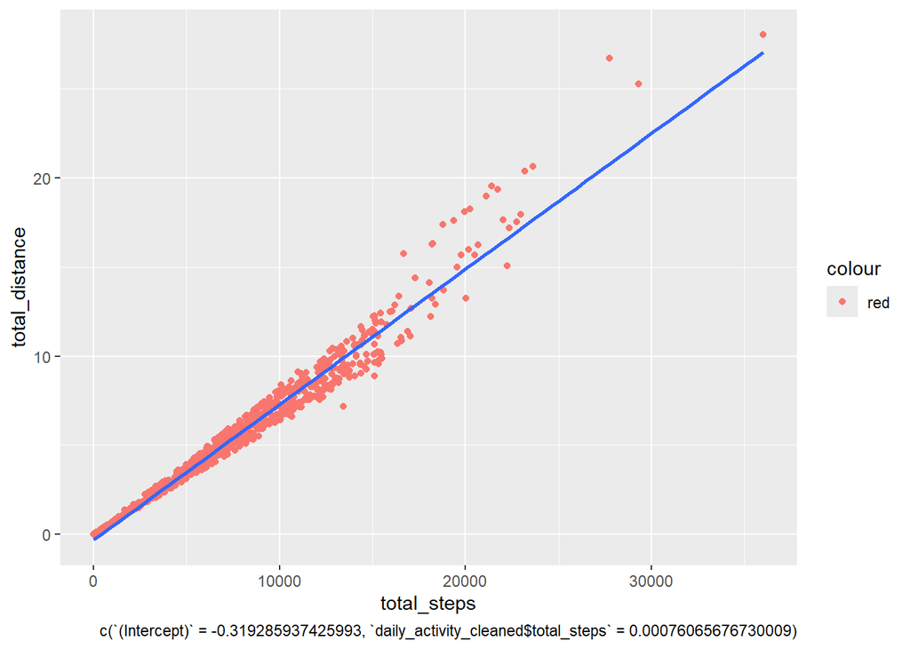

```r
ggplot(data=daily_activity_cleaned, aes(x=total_steps, y=total_distance)) +
  geom_point(aes(color="red")) +
  geom_smooth(method="lm",se=FALSE) +
  labs(caption = lm(daily_activity_cleaned$total_distance ~ daily_activity_cleaned$total_steps))
```

The correlation function indicates that the correlation coefficient between the `total_steps` and `total_distance` is equal to 0.9853688 which indicates that the more steps people take, the greater distance they travel.

We can also check to see if the steps taken per day correlate with sedentary minutes. This will indicate if a low amount of steps taken in a day correspond to higher sedentary minutes which can be used for marketing purposes. Observe the following code

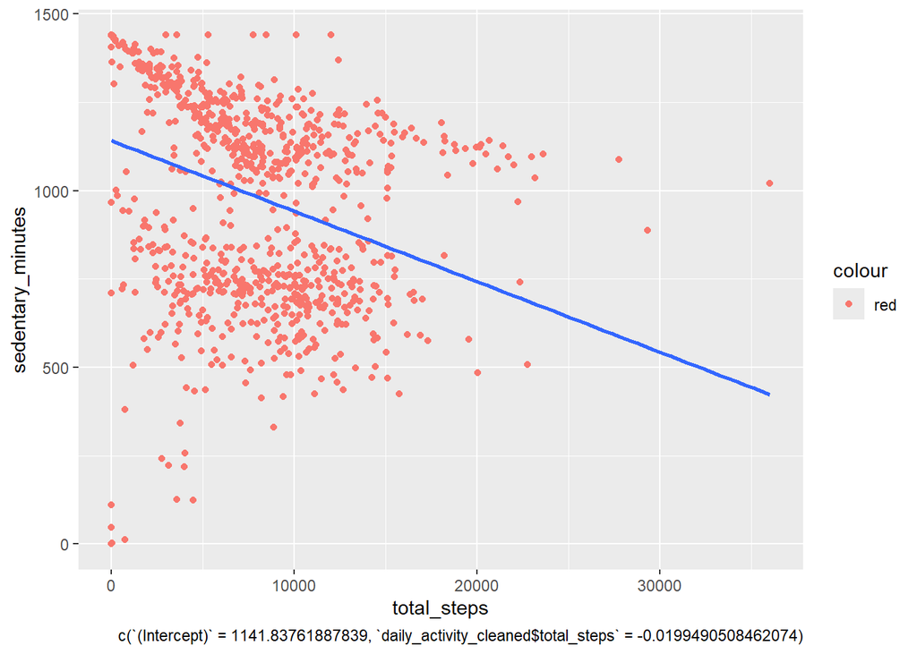

```r
ggplot(data=daily_activity_cleaned, aes(x=total_steps, y=sedentary_minutes)) +
  geom_point(aes(color="red")) +
  geom_smooth(method="lm",se=FALSE) +
  labs(caption = lm(daily_activity_cleaned$sedentary_minutes~ daily_activity_cleaned$total_steps))
```

The correlation function indicates that the correlation coefficient between the `total_steps` and `sedentary_minutes` is equal to -0.3274835 which indicates a very poor negative relationship between the two. In other words, the more steps that a person takes in a day does not signify that they spend fewer minutes sedentary than someone who takes fewer steps in a day.

Another analysis we can look at is the relationship between minutes asleep and time in bed.

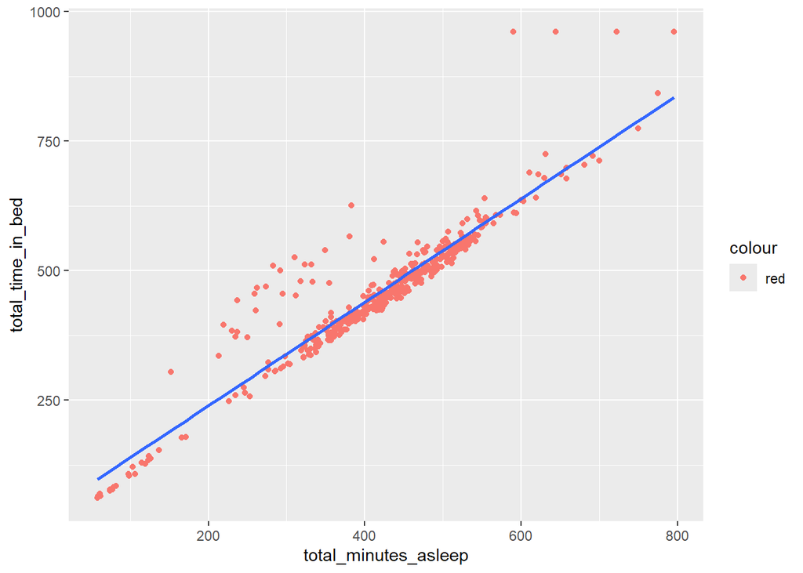

```r
ggplot(data=sleep_day, aes(x=total_minutes_asleep, y=total_time_in_bed)) +
  geom_point(aes(color="red")) +
  geom_smooth(method="lm",se=FALSE)
```

```r
  labs(caption = lm(sleep_day$total_time_in_bed ~ sleep_day$total_minutes_asleep))
```

```
## $caption
##
## Call:
## lm(formula = sleep_day$total_time_in_bed ~ sleep_day$total_minutes_asleep)
##
## Coefficients:
##                    (Intercept)  sleep_day$total_minutes_asleep
##                        39.4627                          0.9993
##
##
## attr(,"class")
## [1] "labels"
```

The correlation between these two variables is 0.9304575 which indicates a strong positive, linear relationship. Some notable outliers are those at the far right extreme who spend the most minutes sleeping, but spend significantly more time in bed than predicted. These deviations occur between 10 to 13 hours of sleep which can indicate an oversleeping pattern that results in more time in bed. To further analyze this trend, the `sleep_day` table can be organized to show the observations of those with the most time in bed:

```r
sleep_day %>%
  arrange(desc(total_time_in_bed)) %>%
  slice(1:10)
```

| id | sleep_day | total_sleep_records | total_minutes_asleep | total_time_in_bed |
| --- | --- | --- | --- | --- |
| 1644430081 | 5/2/2016 12:00:00 AM | 1 | 796 | 961 |
| 1844505072 | 4/15/2016 12:00:00 AM | 1 | 644 | 961 |
| 1844505072 | 4/30/2016 12:00:00 AM | 1 | 722 | 961 |
| 1844505072 | 5/1/2016 12:00:00 AM | 1 | 590 | 961 |
| 5553957443 | 4/30/2016 12:00:00 AM | 2 | 775 | 843 |
| 1927972279 | 4/12/2016 12:00:00 AM | 3 | 750 | 775 |
| 5553957443 | 4/23/2016 12:00:00 AM | 2 | 631 | 725 |
| 4319703577 | 4/23/2016 12:00:00 AM | 1 | 692 | 722 |
| 1503960366 | 4/17/2016 12:00:00 AM | 1 | 700 | 712 |
| 7086361926 | 4/24/2016 12:00:00 AM | 1 | 681 | 704 |

```r
sleeping_pivot_table <- sleep_day %>%
  group_by(id) %>%
  summarise(
    average_minutes_sleeping = mean(total_minutes_asleep, na.rm = TRUE),
    average_time_in_bed = mean(total_time_in_bed, na.rm = TRUE)
  )
print(sleeping_pivot_table)
```

```
## # A tibble: 24 × 3
##            id average_minutes_sleeping average_time_in_bed
##         <dbl>                    <dbl>               <dbl>
##  1 1503960366                     360.                383.
##  2 1644430081                     294                 346
##  3 1844505072                     652                 961
##  4 1927972279                     417                 438.
##  5 2026352035                     506.                538.
##  6 2320127002                      61                  69
##  7 2347167796                     447.                491.
##  8 3977333714                     294.                461.
##  9 4020332650                     349.                380.
## 10 4319703577                     477.                502.
## # ℹ 14 more rows
```

Plotting this data yields the following result.

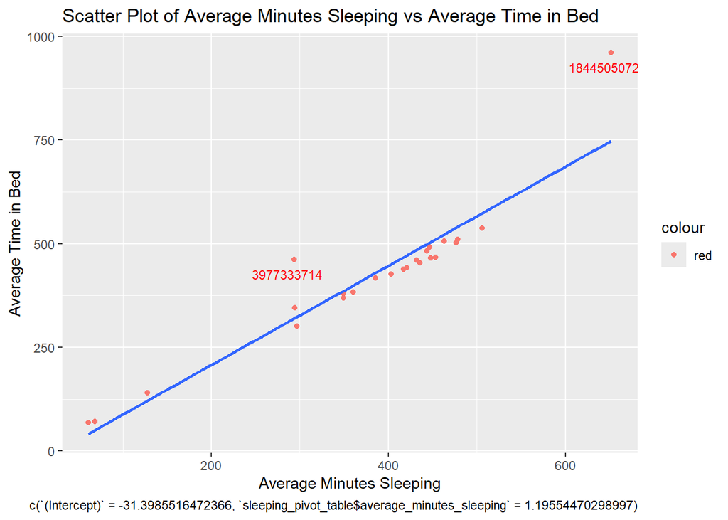

```r
outliers <- c(1844505072, 3977333714)

ggplot(data=sleeping_pivot_table, aes(x=average_minutes_sleeping, y=average_time_in_bed)) +
  geom_point(aes(color="red")) +
  geom_smooth(method="lm",se=FALSE) +
  geom_text(
    data = sleeping_pivot_table %>% filter(id %in% outliers),
    aes(label = id),
    vjust = +2,
    hjust = +0.6,
    color = "red",
    size = 3
  ) +
  labs(
    title = "Scatter Plot of Average Minutes Sleeping vs Average Time in Bed",
    x = "Average Minutes Sleeping",
    y = "Average Time in Bed"
  ) +
  labs(caption = lm(sleeping_pivot_table$average_time_in_bed ~ sleeping_pivot_table$average_minutes_sleeping))
```